# PPG Paint Colors: Final Project - Part 1

Alaa Alghwiri

# 1. Set up the environment

```r
easypackages::libraries("here", "tidyverse", "viridisLite", "ggdist",
                        "distributional", "ggridges", "ggpubr")
```

```
## here() starts at /Users/alghwiri/Library/CloudStorage/OneDrive-UniversityofPittsburgh/Drive Back-up/Acadmics/HDS masters/Taken Courses/Machine Learning
```

```
##
## --------------------------------------------------
## The following packages did not load successfully:
```

# 2. Data exploration

```r
df_orig <- read_csv(here("Final project/paint_project_train_data.csv"))
df_orig %>% glimpse(show_col_types = FALSE)
```

```
## Rows: 835
## Columns: 8
## $ R          <dbl> 172, 26, 172, 28, 170, 175, 90, 194, 171, 122, 0, 88, 144, …
## $ G          <dbl> 58, 88, 94, 87, 66, 89, 78, 106, 68, 151, 121, 140, 82, 163…
## $ B          <dbl> 62, 151, 58, 152, 58, 65, 136, 53, 107, 59, 88, 58, 132, 50…
## $ Lightness  <chr> "dark", "dark", "dark", "dark", "dark", "dark", "dark", "da…
## $ Saturation <chr> "bright", "bright", "bright", "bright", "bright", "bright",…
## $ Hue        <dbl> 4, 31, 8, 32, 5, 6, 34, 10, 1, 21, 24, 22, 36, 16, 26, 12, …
## $ response   <dbl> 12, 10, 16, 10, 11, 16, 10, 19, 14, 25, 14, 19, 14, 38, 15,…
## $ outcome    <dbl> 1, 1, 1, 0, 0, 0, 0, 0, 0, 0, 0, 0, 0, 0, 0, 0, 0, 0, 1, 1,…
```

```r
df <- df_orig %>%
  mutate(y = boot::logit( (response - 0) / (100 - 0) ),
         outcome = ifelse(outcome == 1, 'event', 'non_event'),
         outcome = factor(outcome, levels = c('event', 'non_event'))) %>%
  select(R, G, B, Lightness, Saturation, Hue, y, outcome)
```

## 2.1 The inputs

```r
df %>% group_by(Lightness) %>% summarise(count=n())
```

```
## # A tibble: 7 × 2
##   Lightness count
##   <chr>     <int>
## 1 dark        117
## 2 deep        119
## 3 light       120
## 4 midtone     119
## 5 pale        121
## 6 saturated   119
## 7 soft        120
```

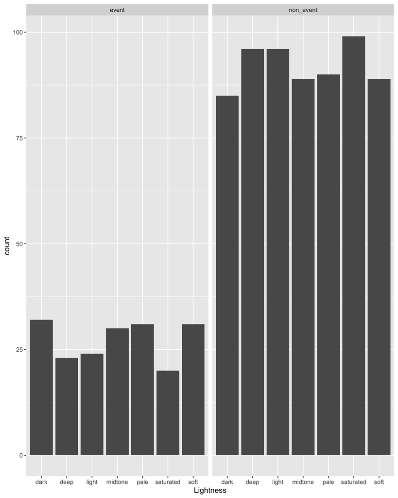

```r
df %>%
  ggplot(mapping = aes(x = Lightness)) +
  geom_bar() +
  facet_wrap(~ outcome)
```

```r
df %>% group_by(Saturation) %>% summarise(count=n())
```

```
## # A tibble: 7 × 2
##   Saturation count
##   <chr>      <int>
## 1 bright       126
## 2 gray          83
## 3 muted        126
## 4 neutral      122
## 5 pure         126
## 6 shaded       126
## 7 subdued      126
```

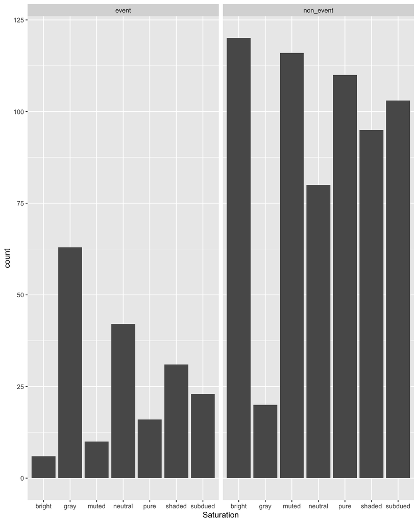

```r
df %>%
  ggplot(mapping = aes(x = Saturation)) +
  geom_bar() +
  facet_wrap(~ outcome)
```

### 2.1.1 The RGB Data

Intuitively, we view the data distribution as a histogram:

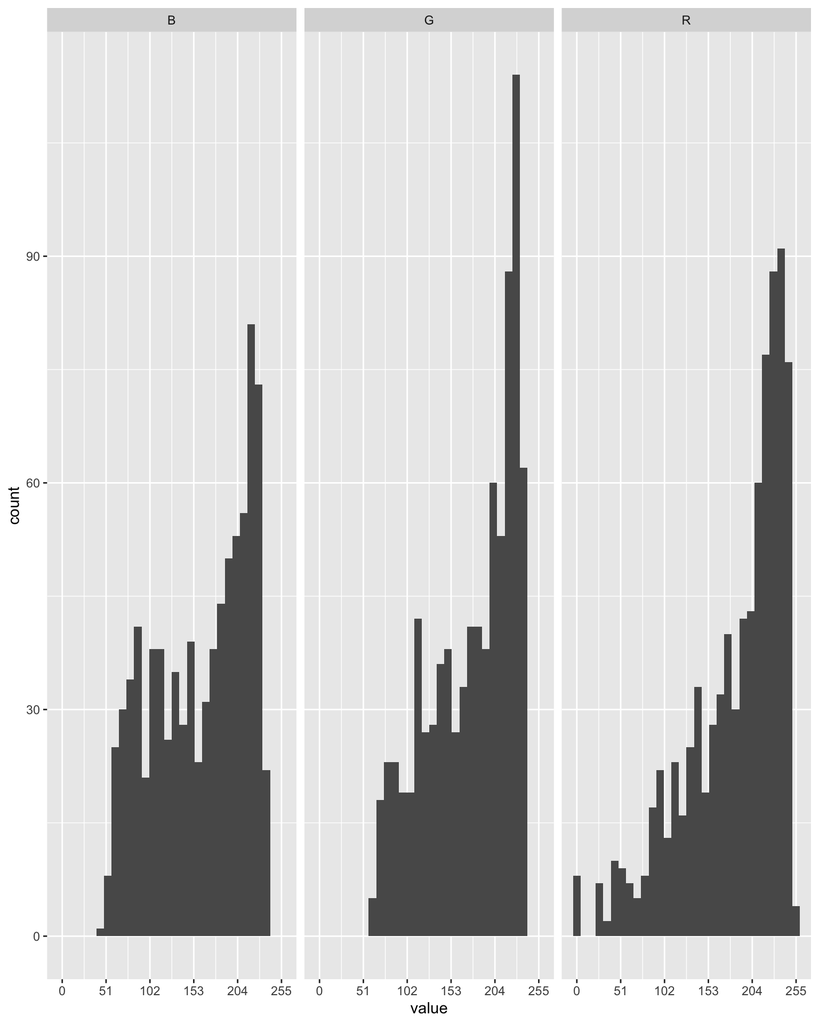

```r
df_RGB <- df %>% select(R, G, B, y, outcome)

df_RGB_long <- df_RGB %>%
  tibble::rowid_to_column() %>%
  pivot_longer(c(R, G, B))

df_RGB_long %>%
  ggplot(mapping = aes(x = value)) +
  geom_histogram(bins = 30) +
  scale_x_continuous(breaks = round(seq(0, 255, by = 51), 1)) +
  facet_wrap(~ name)
```

Or, as a density distribution:

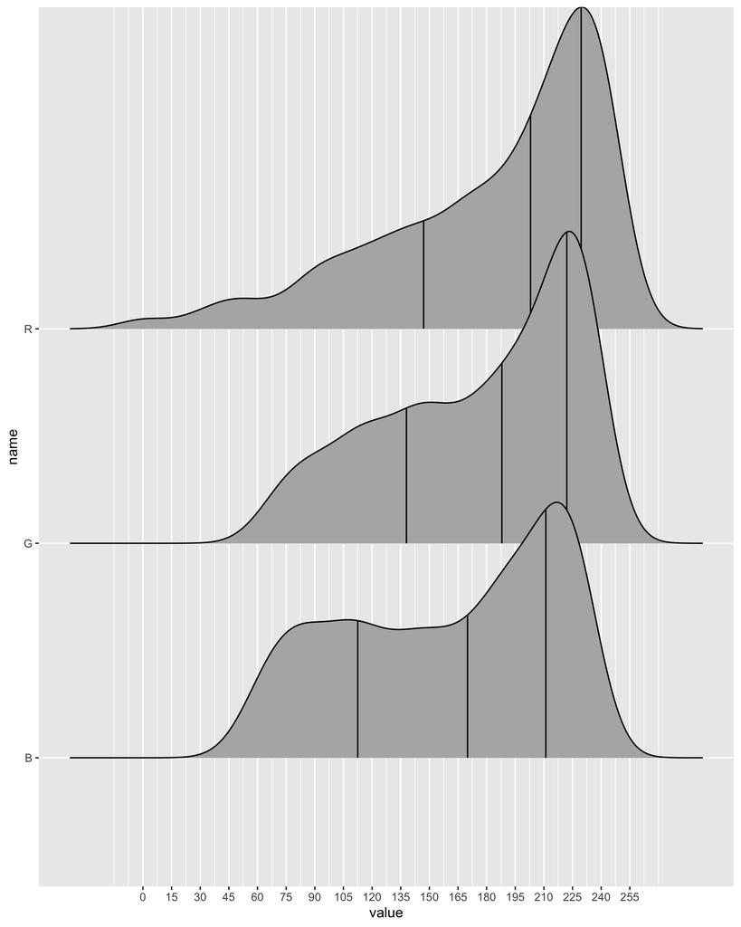

```r
df_RGB_long %>%
  ggplot(mapping = aes(x = value, y = name)) +
  stat_density_ridges(geom = "density_ridges_gradient", calc_ecdf = TRUE,
                      quantiles = 4, quantile_lines = TRUE,
                      scale = 1.5) +
  scale_x_continuous(breaks = round(seq(0, 255, by = 15), 1))
```

When viewed as a whole, the RGB data does not reveal any significant differences. The data show a long-tailed distribution far from a typical Gaussian distribution, and leaning toward the higher part. To further the discussion, we separate the data to view the distribution based on different outcomes:

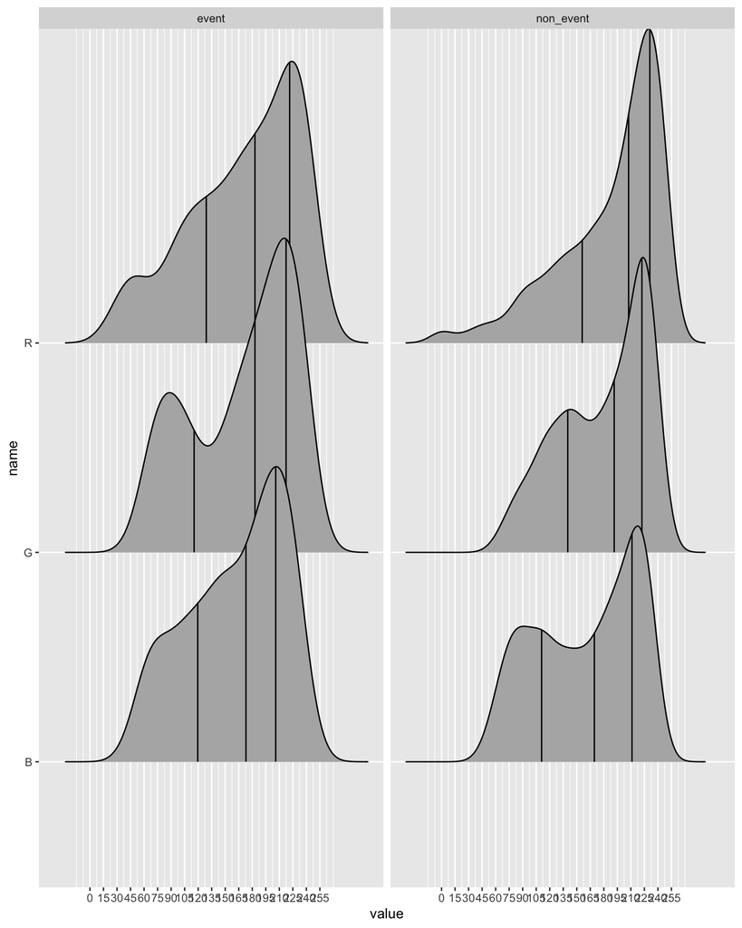

```r
df_RGB_long %>%
  ggplot(mapping = aes(x = value, y = name)) +
  stat_density_ridges(geom = "density_ridges_gradient", calc_ecdf = TRUE,
                      quantiles = 4, quantile_lines = TRUE,
                      scale = 1.5) +
  scale_x_continuous(breaks = round(seq(0, 255, by = 15), 1)) +
  facet_wrap(~ outcome)
```

Further, on the RGB data according to different categorical inputs. For Lightness:

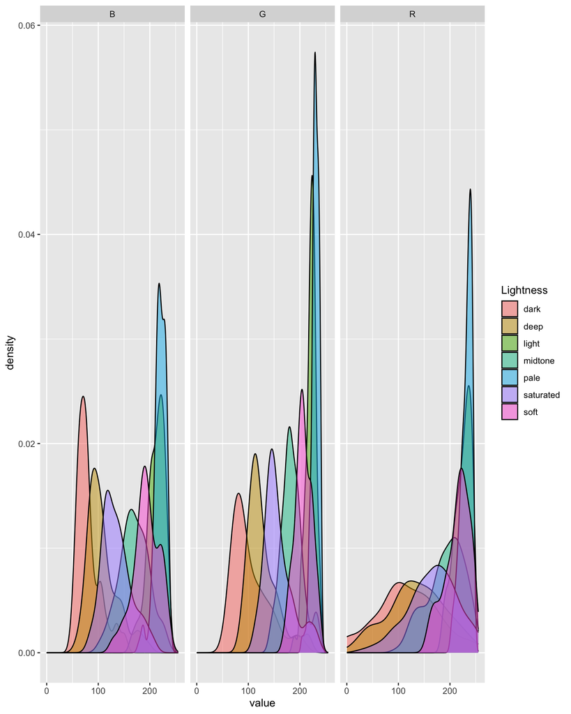

```r
df %>% select(R, G, B, Lightness) %>%
  tibble::rowid_to_column() %>%
  pivot_longer(c(R, G, B)) %>%
  ggplot(mapping = aes(x = value)) +
  geom_density(mapping = aes(fill = Lightness), alpha = 0.5) +
  facet_wrap(~ name)
```

Similarly, for Saturation:

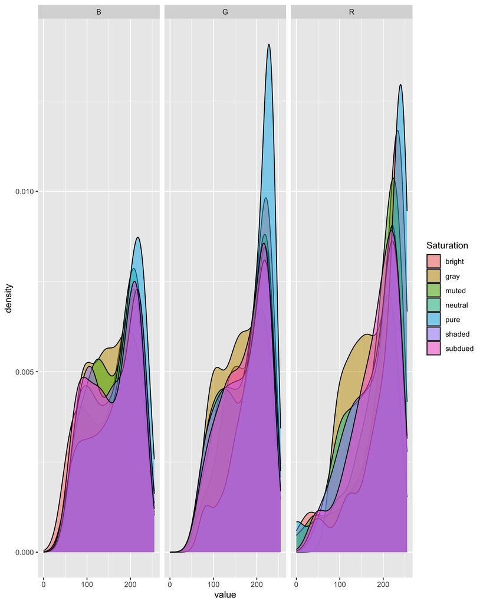

```r
df %>% select(R, G, B, Saturation) %>%
  tibble::rowid_to_column() %>%
  pivot_longer(c(R, G, B)) %>%
  ggplot(mapping = aes(x = value)) +
  geom_density(mapping = aes(fill = Saturation), alpha = 0.5) +
  facet_wrap(~ name)
```

As shown here, the distribution of RGB data is highly dependent on Lightness. Saturation has some influence on the distribution, but is not significant.

Here, we can see that the distribution for the RGB data is clearly different based on the outcome.

Also, we show the correlation matrix between the RGB values:

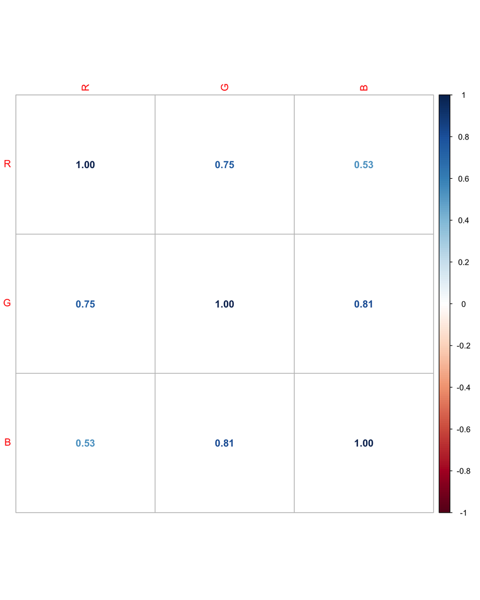

```r
df_RGB %>% select(R, G, B) %>% cor() %>% corrplot::corrplot(method = "number")
```

The RGB data are highly correlated. Now consider the RGB data and the Hue (H) data:

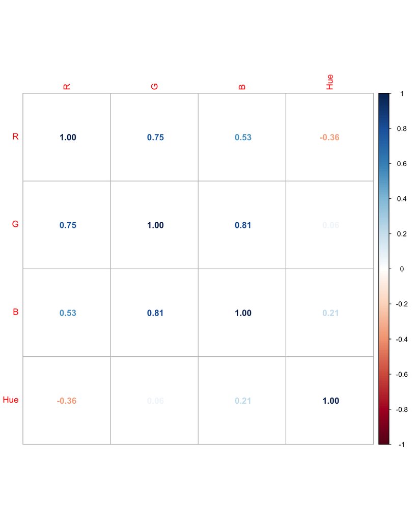

```r
df %>% select(R, G, B, Hue) %>% cor() %>% corrplot::corrplot(method = "number")
```

### 2.1.2 The HSL Data

Same as in 2.1, we view the HSL data:

```r
df_HSL <- df %>%
  select(Hue, Saturation, Lightness, y, outcome)
```

First, the relationship between Saturation (S) and Hue (H):

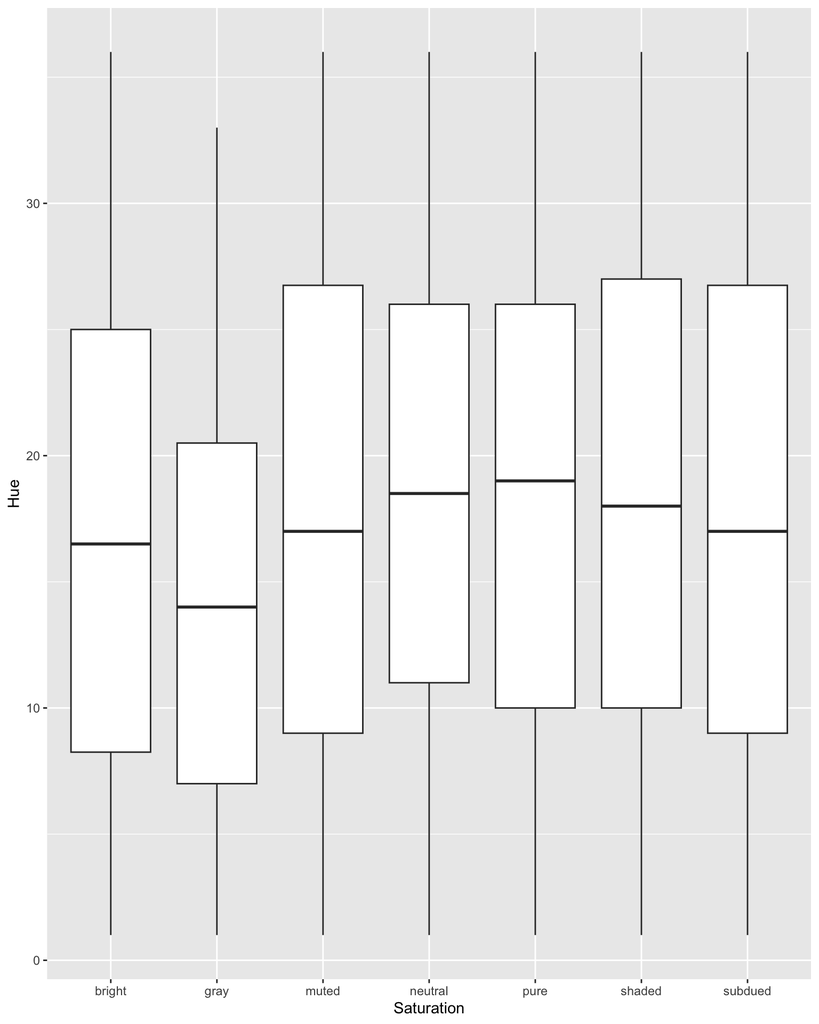

```r
df_HSL %>%
  ggplot(mapping = aes(x = Saturation, y = Hue)) +
  geom_boxplot()
```

[figure not shown]

```r
df_HSL %>%
  ggplot(mapping = aes(x = Saturation, y = Hue)) +
  geom_boxplot()
```

And finally, on the combined influence of Saturation (S) and Lightness (L) on Hue (H):

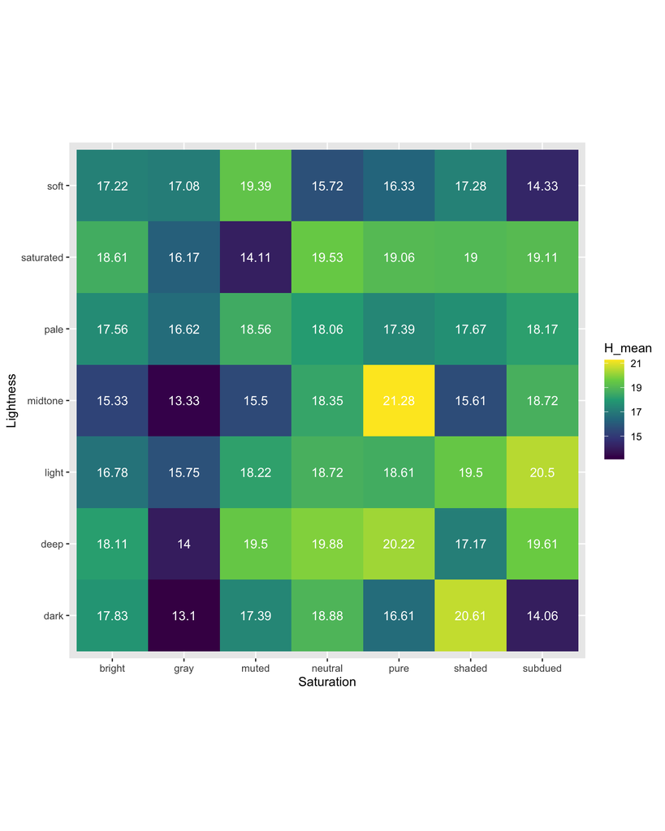

```r
df_HSL %>%
  group_by(Saturation, Lightness) %>%
  summarise_at(vars(Hue), list(H_mean = mean)) %>%
  ggplot(mapping = aes(x = Saturation, y = Lightness, fill = H_mean)) +
  geom_tile() +
  geom_text(mapping = aes(label = round(H_mean, digits = 2)), color = "white") +
  scale_fill_viridis_c() +
  coord_fixed(ratio = 1)
```

Here, we can easily show that the distribution of Hue (H) is largely affected by the combined influence of Saturation (S) and Lightness (L). We also visualize the distribution of Hue (H) with a histogram and a probability distribution:

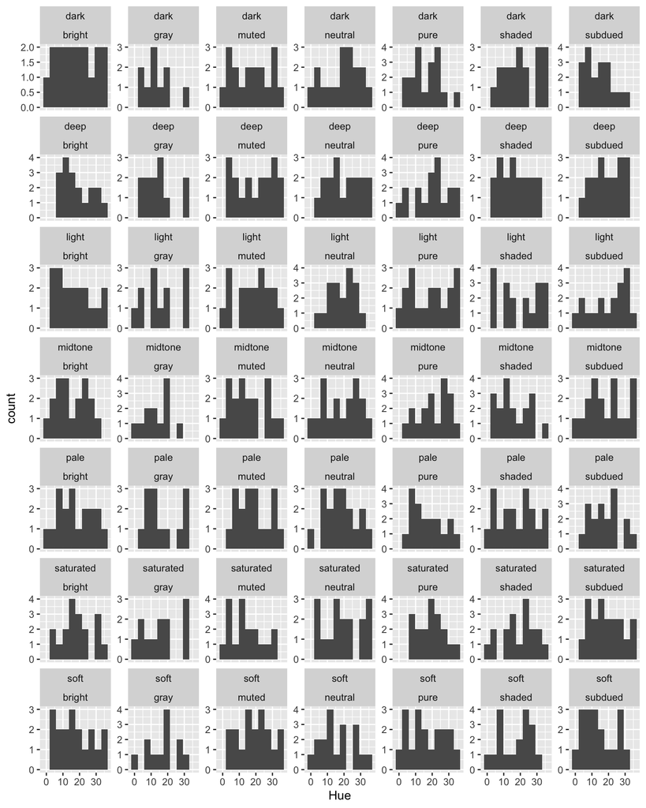

```r
df_HSL %>%
  ggplot(mapping = aes(x = Hue)) +
  geom_histogram(bins = 10) +
  facet_wrap(~ Lightness*Saturation, nrow = 7, scales = "free_y")
```

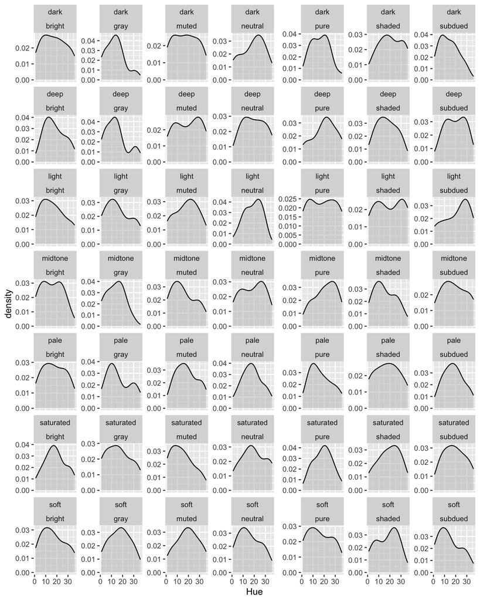

```r
df_HSL %>%
  ggplot(mapping = aes(x = Hue)) +
  geom_density(fill = "gray", alpha = 0.5) +
  facet_wrap(~ Lightness*Saturation, nrow = 7, scales = "free_y")
```

As we can see, the distribution is far from Gaussian.

## 2.2 The continuous output

We first present some basic insights on the continuous output. Here, we plot its distribution:

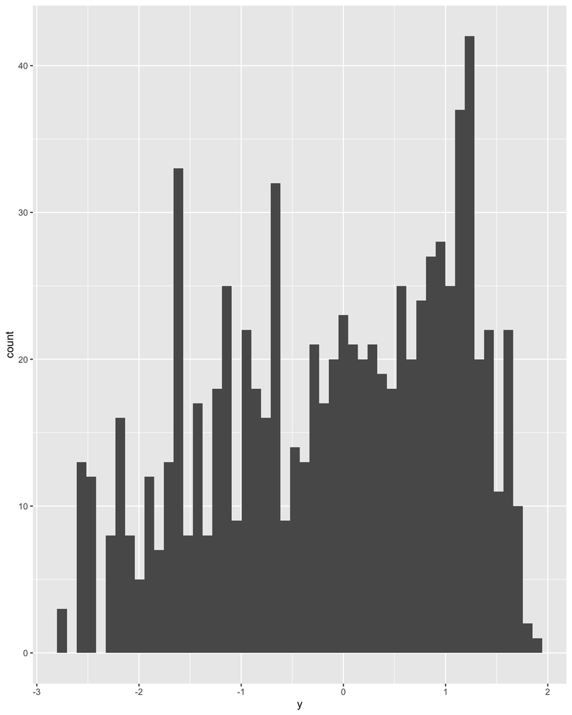

```r
df %>%
  ggplot(mapping = aes(x = y)) +
  geom_histogram(bins = 50)
```

### 2.2.1 The RGB Data Similarly, we plot the relationship for RGB separately:

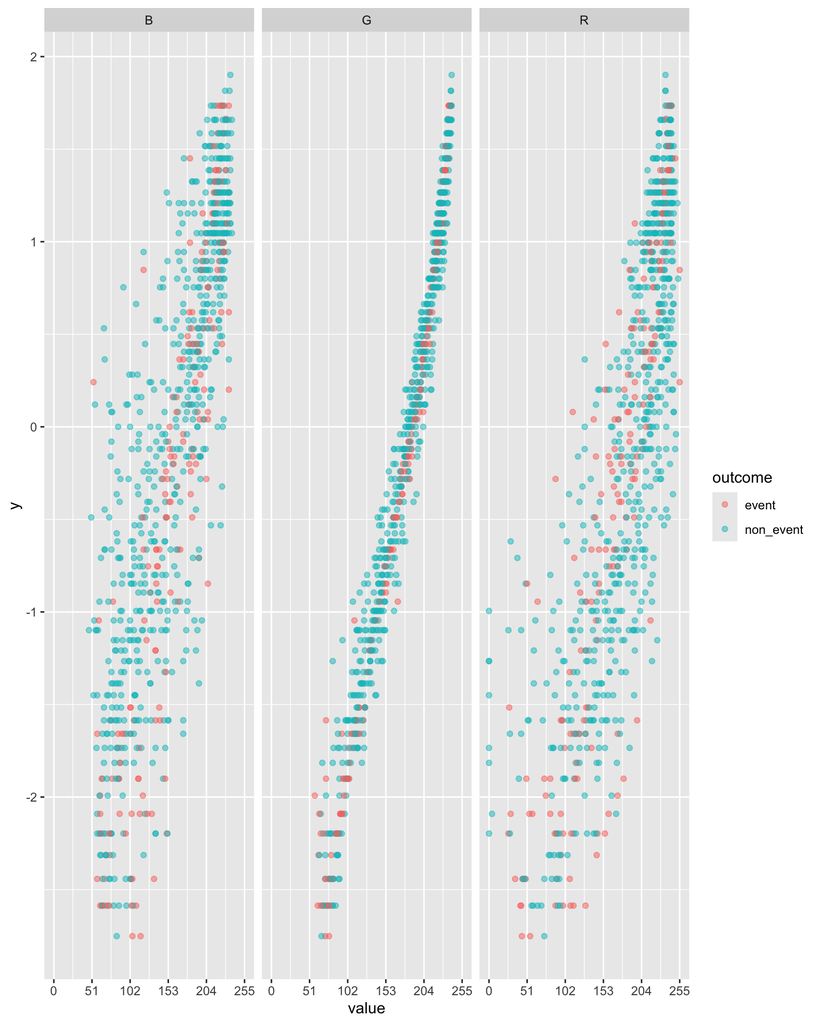

```r
df_RGB_long %>%
  ggplot(mapping = aes(x = value, y = y, color = outcome)) +
  geom_point(alpha = 0.5) +
  scale_x_continuous(breaks = round(seq(0, 255, by = 51), 1)) +
  facet_wrap(~ name)
```

We find that there is a clear trend between the logit-transformed output y and the RGB data: the larger the RGB values are, the larger the y is. Though, we have not discussed the joined influence of RGB data on the output, since the high correlation, the relationship can be unclear.

### 2.2.2 The HSL Data

We first visualize the relationship between Hue (H) and y:

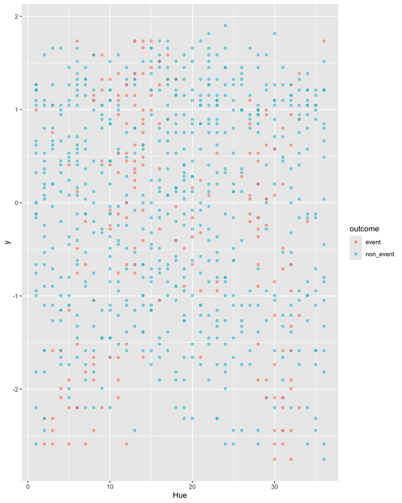

```r
df_HSL %>%
  ggplot(mapping = aes(x = Hue, y = y, color = outcome)) +
  geom_point(alpha = 0.5)
```

It is clear that there is no correlation between the input and the output when viewed alone. Thus, we view the relationship between Hue (H) and y with different Saturation (S) and Lightness (L):

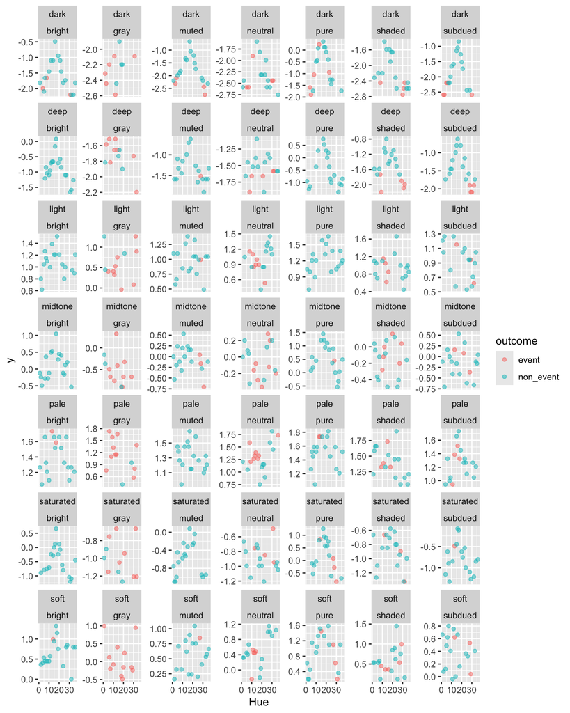

```r
df_HSL %>%
  ggplot(mapping = aes(x = Hue, y = y, color = outcome)) +
  geom_point(alpha = 0.5) +
  facet_wrap(~ Lightness*Saturation, nrow = 7, scales = "free_y")
```

It is therefore clear that the relationship between Hue (H) and y is highly dependent on Saturation (S) and Lightness (L). The relationship can be of non-linear nature, we guess a spline with 2 degrees of freedom.

## 2.3 The Binary Output

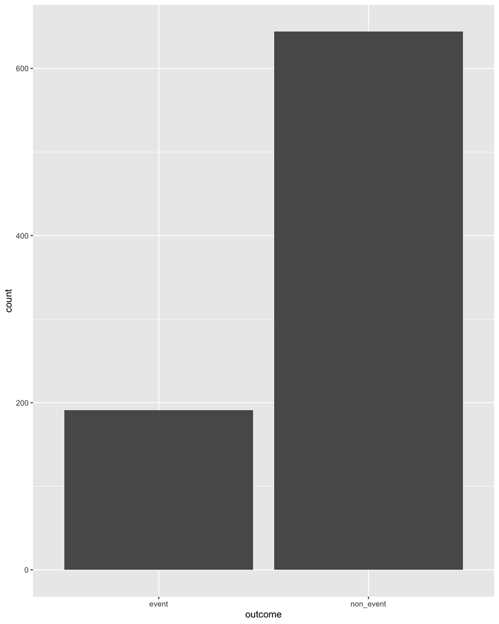

```r
df %>%
  ggplot(mapping = aes(x = outcome)) +
  geom_histogram(stat = "count")
```

We show that it is clearly imbalanced.

### 2.3.1 The RGB Data

For the RGB data, we plot the relationship between the RGB data and the binary output:

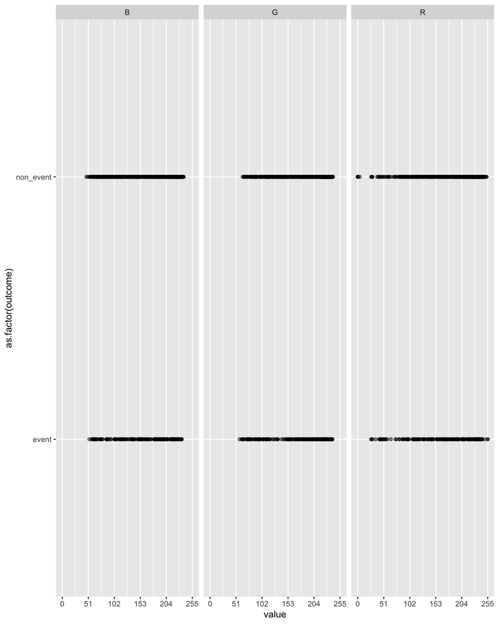

```r
df_RGB_long %>%
  ggplot(mapping = aes(x = value, y = as.factor(outcome))) +
  geom_point(alpha = 0.5) +
  scale_x_continuous(breaks = round(seq(0, 255, by = 51), 1)) +
  facet_wrap(~ name)
```

The data is clearly not linearly separable.

### 2.3.2 The HSL Data

Similarly, we plot the relationship between Hue (H) and outcome:

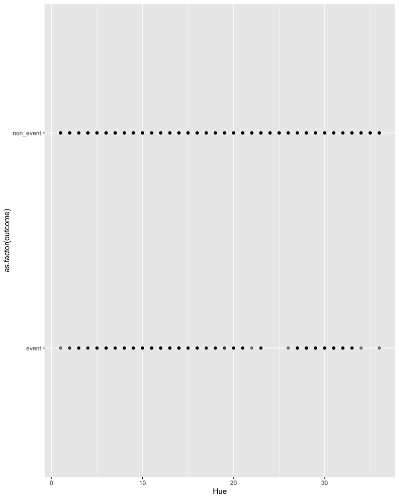

```r
df_HSL %>%
  ggplot(mapping = aes(x = Hue, y = as.factor(outcome))) +
  geom_point(alpha = 0.5)
```

And with different Saturation (S) and Lightness (L):

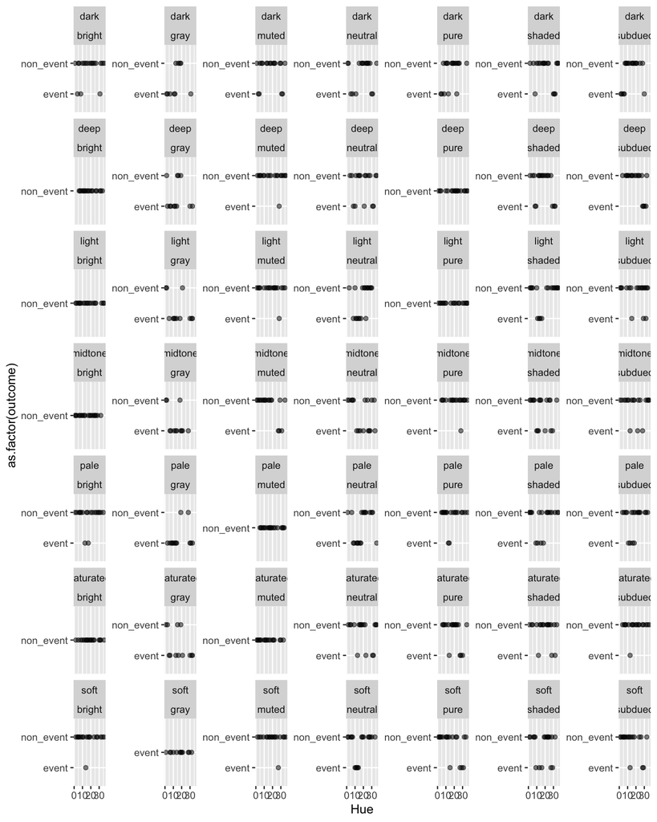

```r
df_HSL %>%
  ggplot(mapping = aes(x = Hue, y = as.factor(outcome))) +
  geom_point(alpha = 0.5) +
  facet_wrap(~ Lightness*Saturation, nrow = 7, scales = "free_y")
```

It is clear that the binary outcome is highly dependent on categorical inputs. Also, we note that in several cases, the data is linearly separable, which could be problematic when training classification models.

# 3. Splitting and Saving Data

```r
set.seed(0)
train_id <- sample(1:nrow(df_orig), size = floor(0.9 * nrow(df_orig)))
df_train <- df_orig %>% slice(train_id)
df_test <- df_orig %>% slice(-train_id)
```

```r
df_train %>% write.csv(here("Final project/Submit/paint_train_split.csv"))
df_train %>% write.csv(here("Final project/Submit/paint_test_split.csv"))
```